# EDA Swire Coca Cola

### **How does seasonal demand impact machine maintenance schedules?**

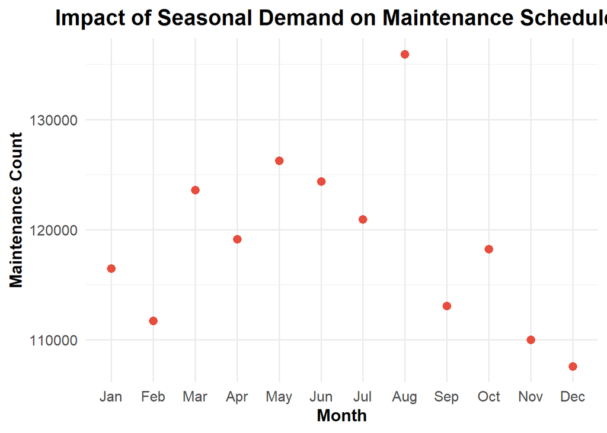

```r
# Seasonal demand impact on maintenance schedules

data %>%
  # Convert EXECUTION_START_DATE to proper date format if needed
  mutate(EXECUTION_START_DATE = ymd(EXECUTION_START_DATE)) %>%
  # Extract the month and assign it as a factor with correct labels
  mutate(month = factor(month(EXECUTION_START_DATE), levels = 1:12,
                        labels = c("Jan", "Feb", "Mar", "Apr", "May", "Jun",
                                   "Jul", "Aug", "Sep", "Oct", "Nov", "Dec"))) %>%
  # Filter out any rows where the month is NA or EXECUTION_START_DATE is missing
  filter(!is.na(month)) %>%
  # Group by month and count the number of maintenance requests for each
  group_by(month) %>%
  summarise(maintenance_count = n(), .groups = "drop") %>%
  # Complete missing months with 0 counts
  complete(month, fill = list(maintenance_count = 0)) %>%
  # Create the plot
  ggplot(aes(x = month, y = maintenance_count)) +
  geom_line(color = "#0073B2", size = 1.5) +  # Line color and thickness
  geom_point(color = "#E74C3C", size = 3) +  # Points with fill color
  geom_smooth(method = "loess", se = FALSE, color = "#8E44AD", size = 1) +  # Smoothing line
  labs(
    title = "Impact of Seasonal Demand on Maintenance Schedules",
    x = "Month",
    y = "Maintenance Count"
  ) +
  theme_minimal(base_size = 15) +  # Use a larger base font size for better readability
  theme(
    plot.title = element_text(hjust = 0.5, size = 18, face = "bold"),  # Center and bold title
    axis.title.x = element_text(size = 14, face = "bold"),  # Bold x-axis title
    axis.title.y = element_text(size = 14, face = "bold"),  # Bold y-axis title
    axis.text.x = element_text(size = 12),  # Adjust x-axis text size
    axis.text.y = element_text(size = 12)   # Adjust y-axis text size
  )
```

## Machine Performance Analysis

### **What are the key performance indicators for each machine type?**

```r
# Calculate key performance indicators (KPIs) for each equipment category
kpi_by_equipment_type <- data %>%
  group_by(EQUIP_CAT_DESC) %>%  # Group by equipment category
  summarise(
    avg_downtime = mean(ACTUAL_WORK_IN_MINUTES, na.rm = TRUE),
    total_breakdowns = n(),
    total_operational_hours = sum(ACTUAL_WORK_IN_MINUTES) / 60,  # Convert minutes to hours
    .groups = "drop"
  )

# View the KPIs
print(kpi_by_equipment_type)
```

```
# A tibble: 5 × 4
  EQUIP_CAT_DESC            avg_downtime total_breakdowns total_operational_ho…¹
  <chr>                            <dbl>            <int>                  <dbl>
1 Machines                          72.5            79224                95792.
2 Plant & Buildings                 78.4               77                  101.
3 Production resources/too…        259.                82                  354.
4 Test/measurement equipme…         78.5               64                   83.7
5 Unknown                           89.6          1347817              2011969.
# ℹ abbreviated name: ¹total_operational_hours
```

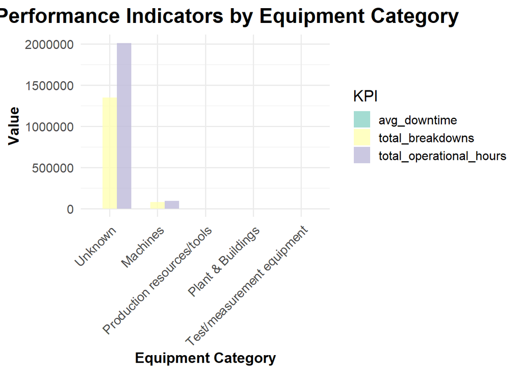

```r
# Plotting the KPIs
kpi_by_equipment_type_long <- kpi_by_equipment_type %>%
  pivot_longer(cols = c(avg_downtime, total_breakdowns, total_operational_hours),
               names_to = "KPI",
               values_to = "Value")

ggplot(kpi_by_equipment_type_long, aes(x = reorder(EQUIP_CAT_DESC, -Value), y = Value, fill = KPI)) +
  geom_bar(stat = "identity", position = "dodge", alpha = 0.8) +  # Separate bars for each KPI
  labs(
    title = "Key Performance Indicators by Equipment Category",
    x = "Equipment Category",
    y = "Value",
    fill = "KPI"
  ) +
  theme_minimal(base_size = 15) +  # Use a larger base font size for better readability
  theme(
    plot.title = element_text(hjust = 0.5, size = 20, face = "bold"),  # Center and bold title
    axis.title.x = element_text(size = 14, face = "bold"),  # Bold x-axis title
    axis.title.y = element_text(size = 14, face = "bold"),  # Bold y-axis title
    axis.text.x = element_text(angle = 45, hjust = 1, size = 12),  # Rotate x-axis labels for better visibility
    axis.text.y = element_text(size = 12)   # Adjust y-axis text size
  ) +
  scale_fill_brewer(palette = "Set3")   # Use a color palette for different KPIs
```

```r
  #coord_flip()  # Flip coordinates for better readability
```

### **How do different maintenance activities affect the performance and uptime of machines?**

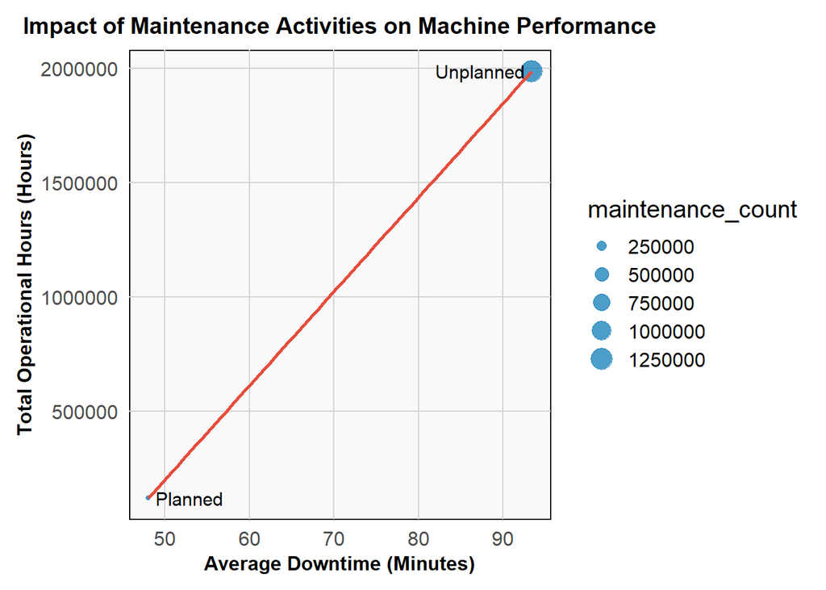

```r
library(ggrepel)

# Summarize operational hours and downtime by maintenance type
maintenance_performance <- data %>%
  group_by(MAINTENANCE_ACTIVITY_TYPE) %>%
  summarise(
    avg_downtime = mean(ACTUAL_WORK_IN_MINUTES, na.rm = TRUE),
    total_operational_hours = sum(ACTUAL_WORK_IN_MINUTES) / 60,  # Convert to hours
    maintenance_count = n(),  # Count the number of maintenance activities
    .groups = "drop"
  )

# Plot the relationship between average downtime and operational hours by maintenance activity
ggplot(maintenance_performance, aes(x = avg_downtime, y = total_operational_hours, label = MAINTENANCE_ACTIVITY_TYPE)) +
  geom_point(aes(size = maintenance_count), color = "#0073B2", alpha = 0.7) +  # Points sized by maintenance count
  geom_text_repel(size = 4, max.overlaps = Inf) +  # Add text labels for each point with repulsion to prevent overlap
  geom_smooth(method = "lm", se = TRUE, color = "#E74C3C") +  # Add a linear regression line with confidence interval
  labs(
    title = "Impact of Maintenance Activities on Machine Performance",
    x = "Average Downtime (Minutes)",
    y = "Total Operational Hours (Hours)"
  ) +
  theme_minimal(base_size = 15) +  # Use a larger base font size for better readability
  theme(
    plot.title = element_text(hjust = 0.5, size = 14, face = "bold"),  # Center and bold title (reduced size)
    axis.title.x = element_text(size = 12, face = "bold"),  # Bold x-axis title
    axis.title.y = element_text(size = 12, face = "bold"),  # Bold y-axis title
    panel.grid.major = element_line(color = "#D3D3D3", size = 0.5),
    panel.grid.minor = element_blank(),
    panel.background = element_rect(fill = "#F9F9F9"),
    plot.margin = margin(10, 10, 10, 10)  # Adjust margins (top, right, bottom, left)
  )
```

This visualization explores the relationship between different maintenance activities and their impact on machine performance, particularly in terms of average downtime and total operational hours. From the plot, it is clear that “Unplanned” maintenance activities are associated with higher average downtime and operational hours, compared to “Planned” activities, which have lower downtime and operational hours. The linear trend between the two suggests that as downtime increases, operational hours also rise, indicating that more downtime correlates with greater operational time, likely due to the nature of unplanned, urgent repairs.